# Education and Attitudes Toward Immigration in the Netherlands

Jinfang Zhang

2025

# Overview

## Background

Attitudes toward immigration vary substantially across individuals and are shaped by a range of social, economic, and demographic factors.

Education is frequently associated with more positive attitudes toward immigration, making it a useful focal predictor for examining variation in immigration attitudes.

This project examines the relationship between education and attitudes toward immigration in the Netherlands using data from Round 10 of the European Social Survey (ESS).

## Research Question

**To what extent is education associated with attitudes toward immigration in the Netherlands?**

The analysis investigates whether respondents with more years of education tend to report more positive attitudes toward immigration and whether this association remains after accounting for sociodemographic, economic, and attitudinal characteristics.

The project demonstrates an end-to-end quantitative analysis workflow in R, including data cleaning, composite index construction, reliability analysis, exploratory visualization, multiple linear regression, robust check, and statistical visualization.

# Analysis

## Data and Variable Construction

The analysis uses ESS Round 10 data and focuses on respondents from the Netherlands.

Attitudes toward immigration are measured using three survey items assessing perceptions of immigration’s:

1. economic impact
2. cultural impact
3. overall impact on the country

Higher values indicate more positive attitudes toward immigration.

The focal independent variable is years of education. Additional variables include age, gender, country of birth, perceived household income, religiosity, household income, cultural values, and social trust.

### Import Data

The raw ESS dataset is not included in this repository.

```r
ESS10 <- read_csv("ESS10.csv")
```

### Select Netherlands Sample

```r
ess_nl <- ESS10 %>%
  filter(cntry == "NL") %>%
  select(
    age = agea,
    gender = gndr,
    born_country = brncntr,
    education = eduyrs,
    household_income = hinctnta,
    religiosity = rlgdgr,
    immigration_economic = imbgeco,
    immigration_cultural = imueclt,
    immigration_country = imwbcnt,
    social_trust = ppltrst,
    cultural_value = imptrad,
    perceived_income = hincfel
  )
```

### Data Cleaning

Special ESS response codes representing responses such as *Don’t know*, *Refusal*, and *No answer* are recoded as missing values.

```r
ess_nl_clean <- ess_nl %>%
  mutate(
    age = na_if(age, 999),

    gender = if_else(
      gender %in% c(7, 8, 9),
      NA_real_,
      as.numeric(gender)
    ),

    born_country = if_else(
      born_country %in% c(7, 8, 9),
      NA_real_,
      as.numeric(born_country)
    ),

    education = if_else(
      education %in% c(77, 88, 99),
      NA_real_,
      as.numeric(education)
    ),

    household_income = if_else(
      household_income %in% c(77, 88, 99),
      NA_real_,
      as.numeric(household_income)
    ),

    religiosity = if_else(
      religiosity %in% c(77, 88, 99),
      NA_real_,
      as.numeric(religiosity)
    ),

    immigration_economic = if_else(
      immigration_economic %in% c(77, 88, 99),
      NA_real_,
      as.numeric(immigration_economic)
    ),

    immigration_cultural = if_else(
      immigration_cultural %in% c(77, 88, 99),
      NA_real_,
      as.numeric(immigration_cultural)
    ),

    immigration_country = if_else(
      immigration_country %in% c(77, 88, 99),
      NA_real_,
      as.numeric(immigration_country)
    ),

    social_trust = if_else(
      social_trust %in% c(77, 88, 99),
      NA_real_,
      as.numeric(social_trust)
    ),

    cultural_value = if_else(
      cultural_value %in% c(7, 8, 9),
      NA_real_,
      as.numeric(cultural_value)
    ),

    perceived_income = if_else(
      perceived_income %in% c(7, 8, 9),
      NA_real_,
      as.numeric(perceived_income)
    )
  )
```

### Construct Immigration Attitude Index

```r
analysis_data <- ess_nl_clean %>%
  mutate(
    gender = factor(
      gender,
      levels = c(1, 2),
      labels = c("Male", "Female")
    ),

    born_country = factor(
      born_country,
      levels = c(1, 2),
      labels = c(
        "Born in Netherlands",
        "Born outside Netherlands"
      )
    ),

    immigration_attitude = rowMeans(
      across(
        c(
          immigration_economic,
          immigration_cultural,
          immigration_country
        )
      ),
      na.rm = FALSE
    )
  ) %>%
  filter(
    education <= 21 | is.na(education)
  )
```

### Reliability

Cronbach’s alpha is used to assess the internal consistency of the three immigration-attitude items.

```r
attitude_items <- analysis_data %>%
  select(
    immigration_economic,
    immigration_cultural,
    immigration_country
  )

alpha_result <- psych::alpha(attitude_items)

alpha_result$total$raw_alpha
```

```
## [1] 0.7795647
```

The three items show acceptable internal consistency (**Cronbach’s α ≈ 0.78**) and are therefore combined into a composite index.

## Exploratory Analysis

Because years of education are recorded as integer values, jittering is used to reduce overplotting.

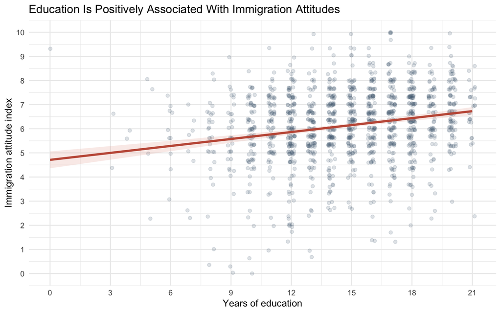

```r
p_relationship <- ggplot(
  analysis_data,
  aes(
    x = education,
    y = immigration_attitude
  )
) +
  geom_jitter(
    width = 0.18,
    height = 0.08,
    alpha = 0.18,
    size = 1.6,
    colour = "#526D82"
  ) +
  geom_smooth(
    method = "lm",
    se = TRUE,
    colour = "#C45A45",
    fill = "#E9B4A7",
    linewidth = 1.2,
    alpha = 0.25
  ) +
  scale_x_continuous(
    breaks = seq(0, 21, 3)
  ) +
  scale_y_continuous(
    breaks = 0:10,
    limits = c(0, 10)
  ) +
  labs(
    title =
      "Education Is Positively Associated With Immigration Attitudes",
    x = "Years of education",
    y = "Immigration attitude index",
  ) +
  theme_minimal()

p_relationship
```

The exploratory relationship is positive: respondents with more years of education tend to report more favorable attitudes toward immigration.

## Regression Analysis

To ensure that coefficient changes across model specifications are not driven by changes in sample composition, all regression models are estimated using the same complete-case sample.

```r
model_data <- analysis_data %>%
  drop_na(
    immigration_attitude,
    education,
    age,
    gender,
    born_country,
    perceived_income,
    religiosity,
    household_income,
    cultural_value,
    social_trust
  )

nrow(model_data)
```

```
## [1] 1168
```

Three regression specifications are estimated:

- **Model 1** estimates the bivariate association between education and immigration attitudes.
- **Model 2** introduces sociodemographic controls.
- **Model 3** adds economic and attitudinal predictors, including social trust and cultural values.

```r
model_1 <- lm(
  immigration_attitude ~ education,
  data = model_data
)

model_2 <- lm(
  immigration_attitude ~
    education +
    age +
    gender +
    born_country +
    perceived_income +
    religiosity,
  data = model_data
)

model_3 <- lm(
  immigration_attitude ~
    education +
    age +
    gender +
    born_country +
    perceived_income +
    religiosity +
    household_income +
    cultural_value +
    social_trust,
  data = model_data
)
```

### Model Comparison

```r
gof_map <- data.frame(
  raw = c(
    "nobs",
    "r.squared",
    "adj.r.squared"
  ),
  clean = c(
    "N",
    "R²",
    "Adjusted R²"
  ),
  fmt = c(
    0,
    3,
    3
  )
)

modelsummary(
  list(
    "Bivariate" = model_1,
    "Controls" = model_2,
    "Extended" = model_3
  ),
  stars = TRUE,
  statistic = "({std.error})",
  gof_map = gof_map,
)
```

|  | Bivariate | Controls | Extended |
| --- | --- | --- | --- |
| (Intercept) | 4.822*** | 4.686*** | 3.370*** |
|  | (0.191) | (0.287) | (0.350) |
| education | 0.090*** | 0.093*** | 0.064*** |
|  | (0.013) | (0.013) | (0.013) |
| age |  | 0.004 | 0.003 |
|  |  | (0.003) | (0.003) |
| genderFemale |  | 0.073 | 0.105 |
|  |  | (0.087) | (0.085) |
| born_countryBorn outside Netherlands |  | 0.832*** | 0.888*** |
|  |  | (0.167) | (0.163) |
| perceived_income |  | -0.158* | -0.070 |
|  |  | (0.071) | (0.078) |
| religiosity |  | 0.005 | 0.017 |
|  |  | (0.013) | (0.013) |
| household_income |  |  | 0.006 |
|  |  |  | (0.019) |
| cultural_value |  |  | 0.156*** |
|  |  |  | (0.034) |
| social_trust |  |  | 0.164*** |
|  |  |  | (0.026) |
| N | 1168 | 1168 | 1168 |
| R² | 0.042 | 0.067 | 0.117 |
| Adjusted R² | 0.041 | 0.062 | 0.110 |

+ p < 0.1, * p < 0.05, ** p < 0.01, *** p < 0.001

Because all three models use the same respondents, changes in the education coefficient across specifications reflect changes in model specification rather than changes in sample composition.

Education remains positively associated with immigration attitudes after the introduction of sociodemographic, economic, and attitudinal characteristics.

## Coefficient Plot

The coefficient plot summarizes the estimated relationships in the extended model and displays 95% confidence intervals.

```r
coefficient_data <- broom::tidy(
  model_3,
  conf.int = TRUE
) %>%
  dplyr::filter(
    term != "(Intercept)"
  ) %>%
  dplyr::mutate(
    term_label = dplyr::case_when(
      term == "education" ~
        "Education",

      term == "age" ~
        "Age",

      term == "genderFemale" ~
        "Female",

      term ==
        "born_countryBorn outside Netherlands" ~
        "Born outside Netherlands",

      term == "perceived_income" ~
        "Perceived income difficulty",

      term == "religiosity" ~
        "Religiosity",

      term == "household_income" ~
        "Household income",

      term == "cultural_value" ~
        "Cultural value",

      term == "social_trust" ~
        "Social trust",

      TRUE ~ term
    ),

    significant = if_else(
      p.value < 0.05,
      "Significant",
      "Not significant"
    )
  )
```

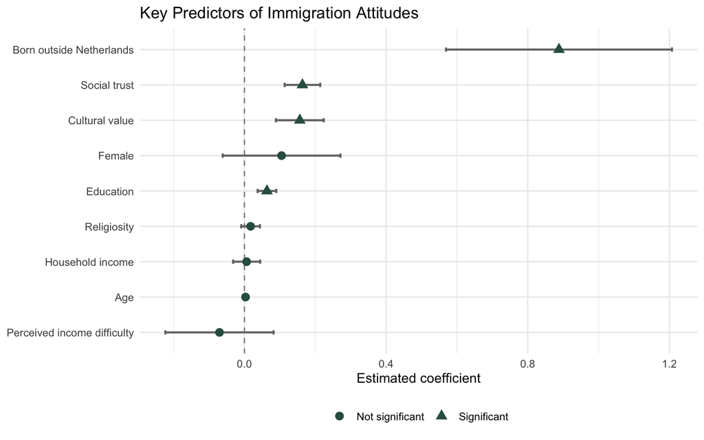

```r
p_coefficients <- ggplot(
  coefficient_data,
  aes(
    x = reorder(term_label, estimate),
    y = estimate
  )
) +
  geom_hline(
    yintercept = 0,
    linetype = "dashed",
    colour = "grey55"
  ) +
  geom_errorbar(
    aes(
      ymin = conf.low,
      ymax = conf.high
    ),
    width = 0.12,
    linewidth = 0.8,
    colour = "grey45"
  ) +
  geom_point(
    aes(
      shape = significant
    ),
    size = 3,
    colour = "#2F5D50"
  ) +
  coord_flip() +
  labs(
    title =
      "Key Predictors of Immigration Attitudes",
    x = NULL,
    y = "Estimated coefficient",
    shape = NULL,
  ) +
  theme_minimal() +
  theme(
    legend.position = "bottom"
  )

p_coefficients
```

# Model Evaluation

## Robust Standard Errors

HC3 heteroskedasticity-robust standard errors are calculated for the extended model.

```r
robust_results <- lmtest::coeftest(
  model_3,
  vcov = sandwich::vcovHC(
    model_3,
    type = "HC3"
  )
)

robust_results
```

```
##
## t test of coefficients:
##
##                                        Estimate Std. Error t value  Pr(>|t|)
## (Intercept)                           3.3700005  0.3864437  8.7205 < 2.2e-16
## education                             0.0636541  0.0135438  4.6999 2.916e-06
## age                                   0.0031735  0.0023704  1.3388    0.1809
## genderFemale                          0.1048963  0.0853085  1.2296    0.2191
## born_countryBorn outside Netherlands  0.8881162  0.1943424  4.5699 5.404e-06
## perceived_income                     -0.0703516  0.0875662 -0.8034    0.4219
## religiosity                           0.0174941  0.0145644  1.2012    0.2299
## household_income                      0.0062766  0.0204722  0.3066    0.7592
## cultural_value                        0.1564394  0.0358047  4.3692 1.359e-05
## social_trust                          0.1637739  0.0286036  5.7256 1.312e-08
##
## (Intercept)                          ***
## education                            ***
## age
## genderFemale
## born_countryBorn outside Netherlands ***
## perceived_income
## religiosity
## household_income
## cultural_value                       ***
## social_trust                         ***
## ---
## Signif. codes:  0 '***' 0.001 '**' 0.01 '*' 0.05 '.' 0.1 ' ' 1
```

The substantive conclusions remain unchanged when HC3 robust standard errors are used.

## Multicollinearity

```r
vif_results <- car::vif(model_3)

vif_results
```

```
##        education              age           gender     born_country
##         1.239981         1.140257         1.023384         1.039479
## perceived_income      religiosity household_income   cultural_value
##         1.329629         1.122196         1.477033         1.104348
##     social_trust
##         1.129648
```

VIF values are low, indicating no meaningful multicollinearity among the predictors.

# Key Findings

- Higher levels of education are consistently associated with more positive attitudes toward immigration across the regression specifications.
- The association remains statistically significant after accounting for sociodemographic, economic, and attitudinal characteristics.
- Social trust and cultural values are also positively associated with immigration attitudes in the extended model.
- The main conclusions remain substantively unchanged when HC3 robust standard errors are used.
- VIF values indicate no meaningful multicollinearity among predictors.

Because all regression specifications use the same complete-case sample, changes across models are not driven by differences in sample composition.

The models explain a modest proportion of variation in immigration attitudes, which is reasonable for an individual-level social attitude outcome influenced by many social and contextual factors.

Because the analysis uses **cross-sectional observational survey data**, the results should be interpreted as statistical associations rather than causal effects.